# Using grattantheme

This vignette explains how to use `grattantheme` to quickly and consistently apply Grattan chart formatting to charts made in `R` using `ggplot`.

When creating a chart using `ggplot` we have to:

- Choose a dataset;
- Map variables to chart aesthetics `aes()`;
- Choose a `geom_`.

For example, using the in-built `iris` dataset:

```r
plot <- ggplot(iris,
               aes(x = Sepal.Length,
                   y = Sepal.Width,
                   colour = Species)) +
        geom_point(size = 4) +
        labs(x = "Species",
             y = "",
             colour = "Species")
```

This successfully plots the data we want to plot:

[figure not shown]

But it doesn’t yet *look* like a Grattan chart. To adjust the *look* we adjust ‘`theme`’ elements, like `axis.ticks.x = element_line(colour = "black")` to adjust the axis tickmarks on the x axis; `panel.grid.major.x = element_blank()` to turn off vertical gridlines; and so on; and on; and on. We also need to adjust aesthetic colours to the Grattan palette; setting, for example, `fill = "#F68B33"`. The `grattantheme` package contains tools and shortcuts to simplify this process.

## Formatting theme elements with `theme_grattan()`

The function `theme_grattan()` contains all of the Grattan `theme` adjustments in one handy command. Combined with `grattan_colour_manual`, which easily changes colours of aesthetics, your `R` chart will be ready for a report or a slide in no time.

```r
plot +
  theme_grattan()
```

[figure not shown]

By default, `theme_grattan()` supresses the legend to allow for clearer on-chart labelling. We can include the legend with the `legend` argument, which takes `"off"`, `"top"`, `"bottom"`, `"left"` or `"right"`:

```r
plot +
  theme_grattan(legend = "top")
```

[figure not shown]

To align the y-axis with zero, change the y scale with `grattan_y_continuous()`:

```r
plot +
  theme_grattan() +
  grattan_y_continuous()
```

[figure not shown]

Sometimes we’ll want a chart for a box in a report. We can change the background colour with the `background` argument:

```r
plot +
  theme_grattan(background = "box") +
  grattan_y_continuous()
```

[figure not shown]

The standard Grattan rules for `x` and `y` axes flip if the chart is a horizontal bar chart. The `x` axis then follows the rules of the `y` axis, and vice-versa. If we are using a ‘flipped’ chart (implemented with `coord_flip()`), we can tell `theme_grattan` this is the case using the argument `flipped` set to `TRUE`.

```r
plot +
  coord_flip() +
  theme_grattan(flipped = TRUE) +
  grattan_y_continuous()
```

[figure not shown]

The final adjustments we can specify with `theme_grattan` are the font size and font family. The defaults meet Grattan formatting requirements, but if we do need to change them we can:

```r
plot +
  theme_grattan(base_size = 8, base_family = "serif") +
  grattan_y_continuous()
```

[figure not shown]

### Font handling

`grattantheme` automatically detects and uses Grattan’s standard fonts when available: - For normal charts: uses system sans-serif fonts - For slide charts: uses DM Serif Display for titles and Avenir Next for body text

The package uses these fonts if they are installed on your computer, and the default sans-serif font otherwise. When you load the package, you’ll see which fonts are being used. If a slide font is missing, install it on your computer; this is the only way for it to appear in PDF and Powerpoint outputs as well as PNGs.

## Using Grattan colours

Grattan’s colours are loaded with `grattantheme`. The HEX codes for individual Grattan colours can be called using `grattan_[colourname]`, eg `grattan_orange`. Colours names are taken from the chart-guide and are:

[figure not shown]

Each of these has eight lighter tints, numbered from `1` (barely lighter) to `8` (closest to white) – so `grattan_orange3` is a light orange. The older `grattan_lightyellow`, `grattan_darkyellow`, `grattan_lightorange`, `grattan_lightred` and `grattan_lightblue` names still work, but they are now just aliases: the palette no longer distinguishes a light and a dark version of those colours.

We can call single colours:

```r
plot +
  geom_hline(yintercept = 3, colour = grattan_orange) +
  geom_vline(xintercept = 6, colour = grattan_darkorange) +
  theme_grattan() +
  grattan_y_continuous()
```

[figure not shown]

We can also use the `scale_fill_grattan()` or `scale_colour_grattan()` functions to change the colours of our fill or colour *aesthetics*. These can be used for discrete/catagorical data (the default) or continuous data.

### Discrete colours

In our example, we have three different flowers each represented by a colour. So we need to set `discrete = TRUE`

```r
plot +
  theme_grattan() +
  grattan_y_continuous() +
  scale_colour_grattan(discrete = TRUE)
```

[figure not shown]

Note that if you need more than 10 colours your chart will not render some of the data. You can set a manual theme using `make_grattan_pal`

```r
ggplot(mtcars, aes(x = mpg, y = hp, colour = as.character(wt))) +
  geom_point() +
  scale_colour_manual(values = make_grattan_pal()(29))
```

[figure not shown]

### Continuous colours

`scale_(colour|fill)_grattan` includes an option for continuous colours: `discrete = FALSE`.

```r
plot2 <- ggplot(iris,
               aes(x = Sepal.Length,
                   y = Sepal.Width,
                   colour = Sepal.Length)) +
        geom_point(size = 5) +
        scale_y_continuous_grattan() +
        labs(x = "")

plot_f <- plot2 +
  theme_grattan() +
  scale_colour_grattan(discrete = FALSE)

plot_f
```

[figure not shown]

## Saving plots with `grattan_save`

The `grattan_save()` function saves your chart in a variety of types. We specify the type with the `type` argument that can take the arguments:

- `"normal"`: a standard report chart size, and the default. [**height** = 14.5cm x **width** = 22.16cm]
- `"wholecolumn`: a taller whole-column chart for reports. [22.16 x 22.16]
- `"fullpage"`: a full-page chart for reports. [22.16 x 44.32]
- `"fullslide"` : to produce charts that look like a slide with the Grattan logo. This option allows notes and sources to accompany the saved figure.
- `"fullslide_narrow"` : as with “fullslide”, but with a narrower chart.
- `"fullslide_half"`: as with “fullslide” but chart is half-size, with space on the right-hand side of the slide for additional annotations.
- `"blog"`: a 23.16cm x 23.16cm square image for the Grattan blog, with a grey title bar, logo, subtitle, chart, and caption. Use `grattan_save_web()` to save web-ready PNGs using the slide font.

You can specify `type = "all"` to save in all formats.

The argument `filename` is required. You can specify a file extension; `.pdf` is standard for Grattan charts for reports and is the default if no extension is specified; `.png` is standard for other media.

Charts will be produced using the `cairo_pdf` device, unless another `device` is specified. Note that installation of `cairo_pdf` may require installation of additional software on your system, such as Xquartz on MacOS.

By default, `grattan_save` will save the chart in a new subdirectory that reflects the name of the chart you provide. If you wish to instead save the chart in the current working directory, you can set `no_new_folder = TRUE`.

`grattan_save()` uses the ggplot2 function `ggsave()` to save your chart. Like `ggsave()`, `grattan_save()` will use the last plot you displayed by default, but you can specify something else with `object`.

Now we can save our Grattan-formatted graph as a normally-formatted report chart:

```r
# Create and store the plot:
plot_final <- plot_f +
              labs(title = "Iris plants are rad!",
                 subtitle = "Width of sepal",
                 x = "Length of sepal",
                 y = "",
                 caption = "Notes: A classic dataset. Source: Fisher (1936)")
```

```r
# Save the plot
grattan_save(filename = "iris.pdf",
             object = plot_final,
             type = "normal")
```

Which produces a chart that can fit into a report. Note that the title, subtitle and notes/sources have been removed.

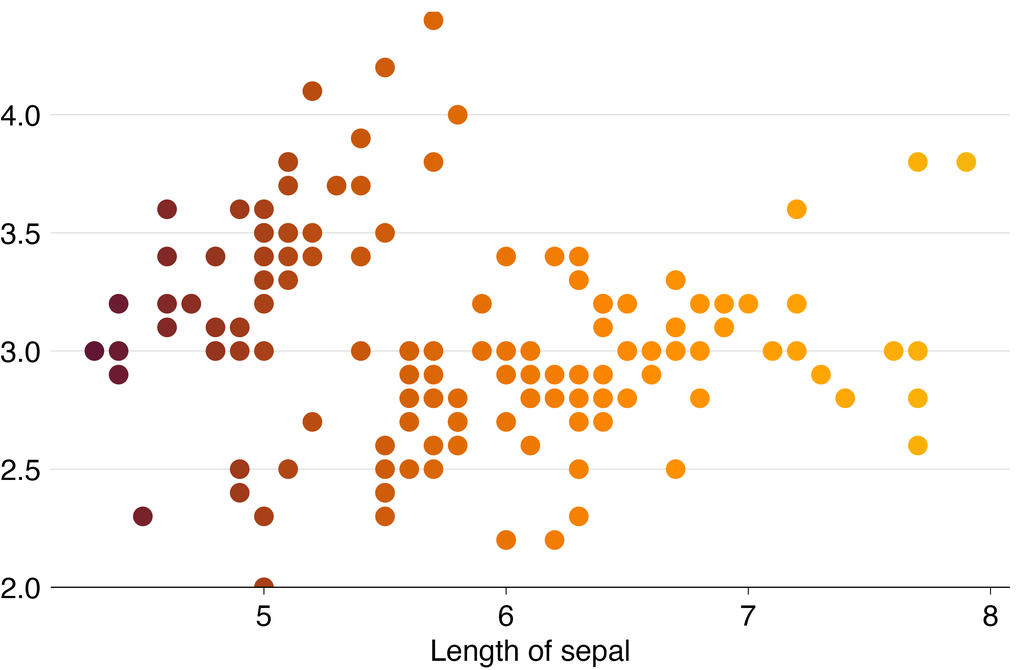

### Box and grey backgrounds

Charts that go in a report box have a light orange background, and blog charts can be light grey all over. Set these when saving, with `background`:

```r
# Report charts (and their Powerpoint slides) get the box's orange
grattan_save("iris.pdf", plot_final, type = "normal", background = "box")

# A blog chart that's grey all over, like its header
grattan_save("iris.pdf", plot_final, type = "blog", background = "grey_blog")

# Both, for every format at once
grattan_save_all("iris.pdf", plot_final, background = c("box", "grey_blog"))
```

The box colour is only used for the report chart types (`normal`, `wholecolumn` and `fullpage`) and their Powerpoint slides. Fullslide, blog and web-ready charts stay white, since they can’t sit in a report box. Label boxes made with `grattan_label()`, `grattan_label_repel()` or `grattan_richlegend()` take the background colour, so they don’t show up as white boxes.

To see how a chart will look, use `check_chart()` with the same `background`, such as `check_chart("normal", background = "box")`. `theme_grattan(background = "box")` still works, and is treated the same as `background = "box"` when you save.

### Saving Powerpoint files

It’s convenient to also save your files in Powerpoint format. This allows PDs to easily use your graphs in their presentations. Saving in this format also means you can include speaker notes – such as information about the script used to create the file – which can help us to keep track of things.

You can save a Powerpoint file, with appropriate speaker notes included, like this:

```r
grattan_save("iris_fullslide.pdf",
             plot_final,
             type = "fullslide",
             save_pptx = TRUE)
```

Or, you can use the `grattan_save_pptx` function, like this:

```r
grattan_save_pptx(plot_final,
                  "iris_fullslide.pptx",
                  type = "fullslide")
```

Note that the `grattan_save_pptx` function does not create a new subdirectory for your file, while `grattan_save` will by default, unless `no_new_folder` is set.

If your chart includes markdown-formatted text either in chart labels or in the chart subtitle, `officer` will often fail to correctly format the Powerpoint slide output. As a workaround, you can use the option `rich_subtitle = T`, which converts both your chart and subtitle to a `.png` file, which is inserted into the Powerpoint slide. This means the content (including fonts) cannot then be edited in Powerpoint after the fact , but will correctly reflect any markdown formatting.

### Saving chart data

When we release reports or working papers, we typically upload an Excel file including ‘chart data’ for most of our charts. The process for making and properly formatting these files can be a bit laborious. `grattantheme` helps streamline that process, using the `save_chartdata()` function.

You can use it like this:

```r
grattan_save("plot_final.png",
             type = "fullslide",
             save_data = TRUE)
```

Or you can use the `save_chartdata` function directly, like this:

```r
save_chartdata("plot_final.xlsx", object = plot_final)
```

### Saving to an Overleaf atlas

Grattan reports are drafted in Overleaf, with charts saved to an ‘atlas’ folder. You can save charts directly from R to your Overleaf project using `grattan_save_overleaf()`.

Charts get to Overleaf one of two ways, and you choose which by how you set the project with `set_overleaf_project()`:

- **Over git**, by giving it your project’s URL. Charts are pushed straight to Overleaf, so nothing needs to be synced to your computer.
- **Via Dropbox**, by giving it a project name. Charts are written to the project folder in your Dropbox, which Dropbox syncs to Overleaf.

Saving a chart works the same either way.

#### Syncing over git

Copy your project’s URL out of your browser’s address bar while the project is open in Overleaf, and hand it to `set_overleaf_project()`:

```r
library(grattantheme)

# Set the Overleaf project
set_overleaf_project("https://www.overleaf.com/project/0123456789abcdef01234567")

# Create and save your chart
plot_final <- ggplot(mtcars, aes(x = wt, y = mpg)) +
  geom_point() +
  theme_grattan()

grattan_save_overleaf("my_chart.pdf", plot_final)
```

Putting that URL in your script is worth doing: it travels with your code, so a colleague who runs your script saves to the same Overleaf project without setting anything up.

The one-off bit of setup is a token. Overleaf’s git integration authenticates with a personal token rather than your password, so the first time you do this on a computer, generate one at overleaf.com/user/settings (under ‘Git integration’) and store it:

```r
set_overleaf_token()
```

That saves the token to your `.Renviron`, so you won’t be asked again. One token covers every Overleaf project you can open, and they last a year.

If you’re saving a batch of charts, push them in one go rather than one at a time:

```r
grattan_save_overleaf("chart1.pdf", plot1, push = FALSE)
grattan_save_overleaf("chart2.pdf", plot2, push = FALSE)

overleaf_push()
```

#### Syncing via Dropbox

If your Overleaf project’s folder syncs locally via Dropbox, give `set_overleaf_project()` a project name instead of a URL, or nothing at all to pick from a menu of the projects in your Dropbox:

```r
library(grattantheme)

# Set the Overleaf project
set_overleaf_project("Orange-Book-2025")  # Searches for matching project name

# Create and save your chart
plot_final <- ggplot(mtcars, aes(x = wt, y = mpg)) +
  geom_point() +
  theme_grattan()

grattan_save_overleaf("my_chart.pdf", plot_final)
```

The function saves only the PDF version of your chart to the atlas folder. No subfolders, PowerPoint slides, or chart data files are created. You can still specify chart types:

```r
# Save as a taller chart
grattan_save_overleaf("tall_chart.pdf", plot_final, type = "wholecolumn")

# Save several types at once
grattan_save_overleaf("my_chart.pdf", plot_final, type = c("normal", "wholecolumn"))

# Save all three report types: normal, wholecolumn and fullpage
grattan_save_overleaf("my_chart.pdf", plot_final, type = "all")
```

To change which project you’re saving to during your session:

```r
set_overleaf_project("transport-report")
grattan_save_overleaf("another_chart.pdf", plot_final)
```

#### Writing statistics to Overleaf

Key numbers quoted in the text of a report can be written to the atlas too, and pulled into the report with `\input{}`. `write_overleaf_tex()` writes a single value, so it fits at the end of a pipe:

```r
mtcars %>%
  summarise(mpg = mean(mpg)) %>%
  pull(mpg) %>%
  write_overleaf_tex("mean-mpg", accuracy = 0.1)
```

In Overleaf, `\input{atlas/mean-mpg}` then shows 20.1. Numbers are written in full unless you set `accuracy`, and text is written as it is. The file ends with a `%`, so LaTeX doesn’t add a space after the value. Like `grattan_save_overleaf()`, it pushes straight to Overleaf unless you set `push = FALSE`.

#### Reading the report from R

`fetch_overleaf_report()` copies the text of your report - `Report.tex`, the files in `chapters/`, the bibliography and the `.tex` files in the atlas - into a `report_cache/` folder in your working directory:

```r
fetch_overleaf_report()
```

This is useful for checking the report against your analysis, or for letting an AI assistant such as Claude Code read the latest draft. The copy is read-only and is never sent back to Overleaf: make changes in Overleaf itself. Run `fetch_overleaf_report()` again to refresh it.